# Linear Functions

# Outline: Linear Functions

- Linear and affine functions
- Taylor approximation
- Regression model

# Outline: Linear Functions

- **Linear and affine functions**
- Taylor approximation
- Regression model

# Superposition and linear functions

Notation: The notation $f:\mathbb{R}^n \rightarrow \mathbb{R}$ means $f$ is a function mapping $n$-vectors to numbers.

Definition: We say that $f$ satistifies the superposition property if:

$$f(\alpha x + \beta y) = \alpha f(x) + \beta f(y)$$

holds for all scalars $\alpha, \beta$ and all $n$-vectors $x, y$.

Definition: A function that satisfies superposition is called linear.

# Example: the inner product function

Definition: For $a$ an $n$-vector, the inner product function is defined as

$$f(x) = a^Tx = a_0x_0 + ... + a_{n-1}x_{n-1}.$$

We see that $f(x)$ is a weighted sum of the entries of $x$.

Exercise: Show that the inner production function is linear

# Example: the inner product function

In Python:

```python
import numpy as np

a = np.array([-2, 0, 1, -3])
f = lambda x: np.inner(a, x); f
```

```
<function __main__.<lambda>(x)>
```

```python
x, y = np.array([2, 2, -1, 1]), np.array([0, 1, -1, 0])
alpha, beta = 1.5, -3.7
```

```python
lhs, rhs = f(alpha * x + beta * y), alpha * f(x) + beta * f(y)
lhs, rhs
```

```
(-8.3, -8.3)
```

# All linear functions are inner product functions

Proposition:

- If $f: \mathbb{R}^n \rightarrow \mathbb{R}$ is linear,
- Then $f$ can be expressed as $f(x) = a^T x$ for some $n$-vector $a$. Specifically, $a$ is given by $a_i = f(e_i)$ for $i$ in $\{0, ..., n-1\}$.

Exercise: If $f(x) = a^T x$, show that $a_i = f(e_i)$.

In Python:

```python
a = np.array([-2, 0, 1, -3])
f = lambda x: np.inner(a, x)

e0 = np.array([1, 0, 0, 0])
f(e0)
```

```
-2
```

# Affine functions

Definition: A function that is linear plus a constant is called affine. Its general form is:

$$f(x) = a^Tx+b \quad \text{with $a$ an $n$-vector and $b$ a scalar}$$

Proposition: A function $f:\mathbb{R}^n \rightarrow \mathbb{R}$ is affine if and only if:

$$f(\alpha x + \beta y) = \alpha f(x) + \beta f(y)$$

for all scalars $\alpha, \beta$ with $\alpha + \beta = 1$ and all $n$-vectors $x, y$.

# Linear versus affine functions

- $f$ is linear
- $g$ is affine, not linear

[figure not shown]

😱 Sometimes people refer to affine functions as linear.

# Outline: Linear Functions

- Linear and affine functions
- **Taylor approximation**
- Regression model

# Gradient of a function

Definition: The gradient of $f$ at the $n$-vector $z$ is defined as the $n$-vector $\nabla f(z)$ as:

$$\nabla f(z) = \left(\frac{\partial f}{\partial x_1}(z), ..., \frac{\partial f}{\partial x_n}(z)\right).$$

Exercise: Consider $f(x) = x_1 + (x_2 - x_1)^3$ defined for any $2$-vector $x$. Compute the gradient of $f$.

# Gradient of a function

Consider the function $f : \mathbb{R}^2 \rightarrow \mathbb{R}$.

[figure not shown]

The arrows represent the gradient of $f$ at different points in $\mathbb{R}^2$.

# Gradient of a function

In Python, we can use the package `jax` to compute gradients.

```python
import jax

f = lambda x: x[0] + (x[1] - x[0]) ** 3
grad_f = jax.grad(f)

grad_f(np.array([1., 2.]))
```

```
DeviceArray([-2.,  3.], dtype=float32)
```

[figure not shown]

# First-order Taylor approximation

Definition: Take $f: \mathbb{R}^n \rightarrow \mathbb{R}$. The first-order Taylor approximation of $f$ near the $n$-vector $z$ is

$$\hat{f}(x) = f(z) + \nabla f (z)^T (x - z) = f(z) + \frac{\partial f}{\partial x_1}(z) (x_1 - z_1) + ... + \frac{\partial f}{\partial x_n}(z) (x_n - z_n).$$

- $\hat{f}(z) = f(z)$
- $\hat{f}(x)$ is very close to $f(z)$ when $x$ is very close to $z$.

# First-order Taylor approximation

[figure not shown]

- The first-order Taylor approximation provides an affine approximation *near $z$* to a function that is not affine.
- 😱 This is a good approximation of $f$ only if $x$ is near $z$.

# First-order Taylor approximation

In Python:

```python
f = lambda x: x[0] + (x[1] - x[0]) ** 3
grad_f = jax.grad(f)
```

```python
z = np.array([1., 2.])
f_hat = lambda x: f(z) + np.inner(grad_f(z), (x - z))

f(z), f_hat(z)
```

```
(2.0, 2.0)
```

```python
close_to_z = np.array([1.01, 2.02])
f(close_to_z), f_hat(close_to_z)
```

```
(2.0403010000000004, 2.04)
```

```python
far_from_z = np.array([-1., -2.])
f(far_from_z), f_hat(far_from_z)
```

```
(-2.0, -6.0)
```

# Outline: Linear Functions

- Linear and affine functions
- Taylor approximation
- **Regression model**

# Regression

Definition: A regression model is the affine function of $x$ defined as

$$\hat y = x^Tw + b$$

where:

- $x$ is an $n$-vector, called a feature vector,
- the elements $x_i$s of $x$ are called regressors,
- the $n$-vector $w$ is called the weight vector,
- the scalar $b$ is called the offset or the intercept, and sometimes the bias,
- the scalar $\hat y$ is called the prediction -- of some actual outcome denoted $y$.

# Example: House prices

Example: Model of house prices:

- y is selling price of house in $1000 (in some location, over some period)
- regressor is x = (house area, # bedrooms) (house area in 1000 sq.ft.)
- regression model weight vector and offset are:

$$w = (148.73, −18.85), b = 54.40$$

In Python, we can use this function to return predictions for each house based on beds and area.

```python
w, b = np.array([148.73, -18.85]), 54.40
y_hat = lambda x: np.inner(x, w) + b

area, n_beds = 0.846, 1
price = y_hat(np.array([area, n_beds])); price
```

```
161.37557999999999
```

# Example: House prices

In Python, we evaluate how our model compares to real observed data stored in a csv file.

```python
import pandas as pd

data = pd.read_csv("data/02_houses.csv")
```

```python
price = data["price"]; area = data["area"]; beds = data["beds"]
y_hat_values = np.array([w[0] * area + w[1] * beds]) + b
```

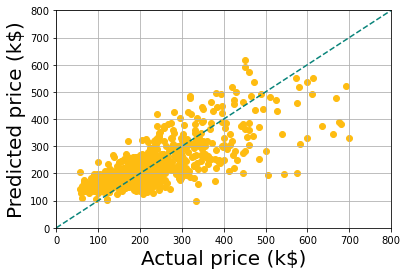

```python
import matplotlib.pyplot as plt

plt.scatter(price, y_hat_values, color='#FEBC11')
plt.plot([0, 800],[0, 800], linestyle='dashed', color='#09847A')
plt.xlabel("Actual price (k$)", fontsize=20)
plt.xlim(0, 800)
plt.ylabel("Predicted price (k$)", fontsize=20)
plt.ylim(0, 800)
plt.grid(True)
```

# Conclusion: Linear Functions

- Linear and affine functions
- Taylor approximation
- Regression model

# Resources

- Ch. 2 of VMSL